# Module 3: Vibe-coding (with spatial data)

Demonstraing vibe-coding workflow using spatial data

Author

Affiliation

[Ben/Paul](https://bfanson.github.io/2026_Workshops/)

Arthur Rylah Institute

Published

October 20, 2026

# Module objectives

1. Explain what is “vibe-coding”
2. Discuss how to implement a vibe-coding workflow within

[figure not shown]

3. Demonstrate vibe-coding approach using spatial data

# Presentation approach today

Today is a pick your own adventure😊

- **Option1:** sit-back and absorb…🪱 tapeworm strategy
- **Option2:** run in parallel…🐒 monkey strategy (monkey see, monkey do)
  - Option 2 is better if you are familiar in Rstudio/R project workflow already
  - If you do Option2, we will be curious to see your outputs (e.g. how it goes for you)

# Let’s chat about a vibe-coding (🪱)

[figure not shown]

## *Fact - A:* Coding is a gateway to lots of tools

It gives you access to…

- Thousands of specialised R packages
- Geospatial tools such as QGIS and PostGIS
- Statistical and biometrics methods that are often only available through code
- Access to database and data engineering tools

## *Fact - B:* LLMs can write really good code (Module1)

(*We discussed in module 1 so will not dwell on…*)

**Advantages**

- Trained on billions of lines of code, documentation, tutorials, and technical discussions
- Have “seen” solutions to many common programming problems before
- Can generate working code in seconds
- Often better at spotting syntax errors than average programmers
- Can use thousands of packages and functions that no human could memorise
- coding is very logical/systematic…(perfect for machines)

## *Fact - C:* You have lots of potentially great ideas

[figure not shown]

Coming up lots of ideas is often easy

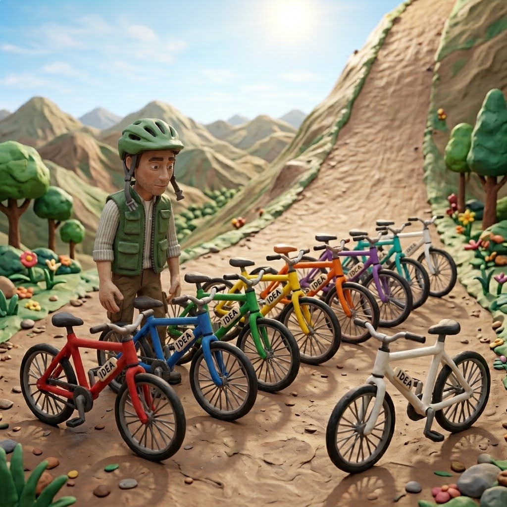

But “testing riding them” (aka seeing if the idea is actually any good) can be a hurdle to ever exploring them.

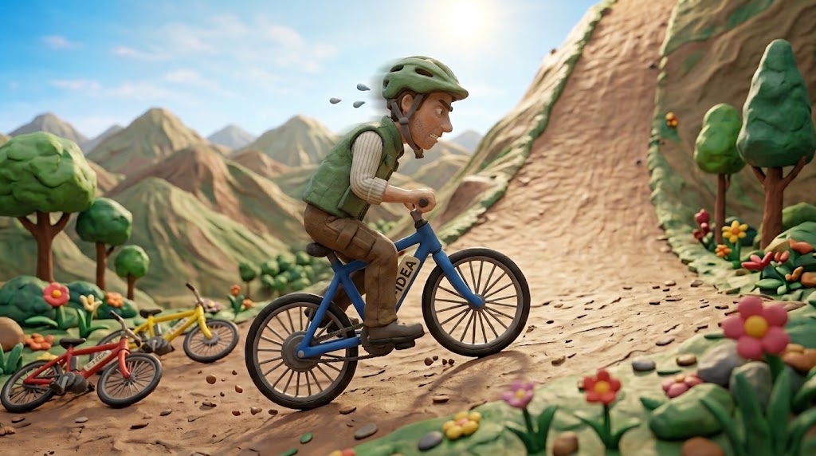

## Given **Fact A** and **Fact B**, why not have LLMs write code for you so you can test ride those ideas (**Fact C**)?

Using LLM to write lowers the cost of “testing riding them”

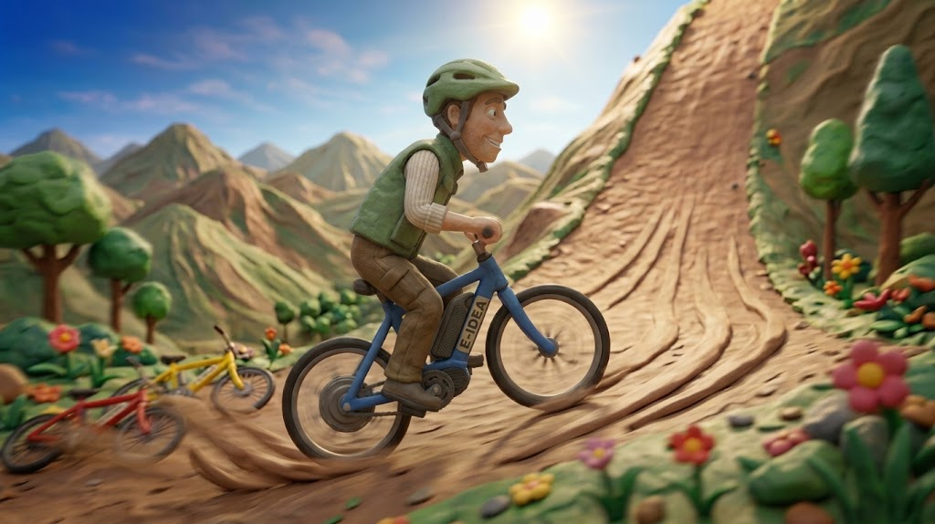

## What is vibe-coding?

As with lots of terminology in the AI boom, defining vibe-coding is a bit nebulous. Different people (and bots!) use the term differently. For our purposes, let’s keep it simple:

**Vibe-coding is a workflow where you describe what you want in natural language, an LLM writes the code, and you iteratively refine the result until you achieve the desired outcome in a reproducible way.**

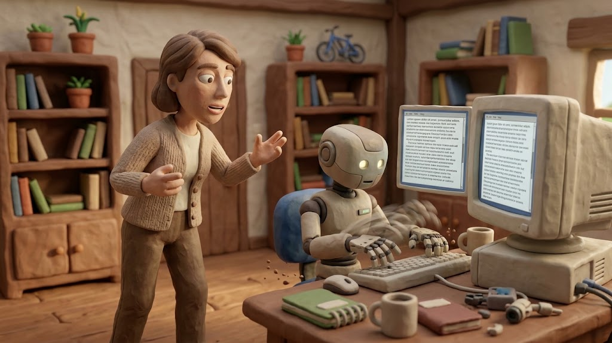

## Caveats with vibe-coding

Vibe-coding can be incredibly productive, but it comes with risks…

- failing into the trap of intellectual laziness
- accept incorrect results in which is the logic does not make sense
- use inappropriate statistical or analytical methods

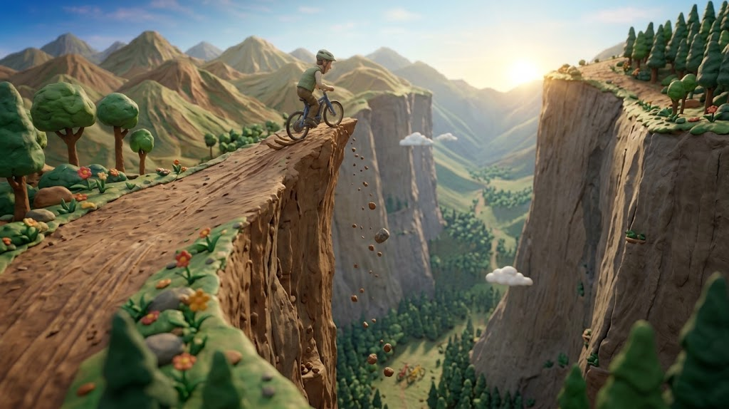

# Implementing a vibe-coding workflow

## Rationale

Some attributes of a good workflow for vibe-coding…

- reproducible
- makes it efficient to review the code and outputs
- aligns with the coding skills and workflow that are already in-house (@ARI)
- leverages proven workflows

## Example Rstudio/R workflow

Here, we will implement vibe-coding within Rstudio environment (which we have presented previously in our workshops😁)

Reminder of key aspects of this workflow…

- Projects (called Rprojects with ext .Rproj ) are the basis
- Structure of directory like the following…

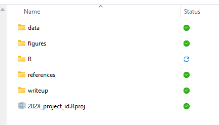

Key bits…

- `data/` folder is treated as locked [do not edit]
- `R/` folder holds your scripts [aka documentation of your steps/logic]

## Other workflows exist?

Yes, lots…

honestly, we do not keep track of but between other programming languages (e.g. Python, C++) and LLMs studios (e.g. Claude Code, Codex) and bespoke software, there are lots.

Of course, what we say here on 20 October 2026 may be antiquated in a year (…as well as lots of other way we do things😕).

# Set-up for Today

## Data files used today (🐒)

As mentioned above, the workflow used here relies on Rstudio/R approach.

Therefore, if you want to be 🐒, you must have Rstudio/R installed for this and be familiar with it.

Click on [Download project folder](https://delwpvicgovau-my.sharepoint.com/:u:/g/personal/ben_fanson_deeca_vic_gov_au/IQDIhnDK4oetTZHoGvAH6TVyAW_-nEiyoGFpIACwkURv4b0) to get the Copilot project folder for the next section of the module.

## Vibe-coding goal for today

A reminder on module2 QGIS map Adrian made…

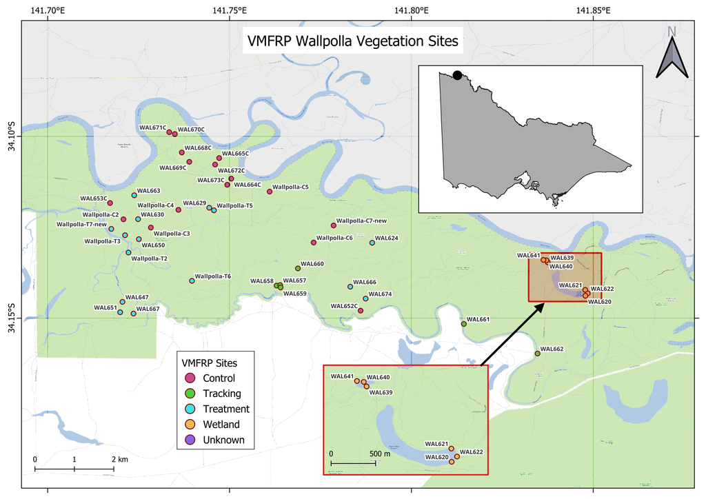

# Copilot Approach (🐒, 🪱)

Currently all ARI staff have access to Microsoft Copilot (Basic)[^1], so that is our starting point when it comes to vibe coding.

Vibe-coding with a Chatbot LLM (like Copilot) is effectively like having a conversation with someone who has read lots of stuff, so may appear knowledgable, but does not understand the topic you are going to discuss with them. Add to that they are often trying to be helpful and positive and that means that they are not always trustworthy, as they can hallucinate when giving an answer it thinks you want. So, they can be useful as sounding board and help with tasks, but you need to be aware that currently, they may unintentionally(?) mislead you.

A good starting point for any project is to plan what you are wanting to do before you start doing. This can help you define your problem and reduce the number of unproductive paths you take on the way to your solution. Let us start by using Copilot to help us devise and clarify a plan of attack for our project. Note, that as well as text, we can add [certain types of files](https://support.microsoft.com/en-us/microsoft-365-copilot/file-formats-supported-by-microsoft-365-copilot) into the prompt window that Copilot can review and help us with our task. So, as well as the text below, we will add the final map from the QGIS workshop as a reference and the summary data of the locations (Copilot didn’t like the GIS data in the .gpkg format).

> I need to create a png map using an R workflow. I have a graph attached (qgis_goal.png) that I want you to replicate. I first want to create a plan that we argue on to create similar map output (to be stored in ‘figures/rmap.png’) and all points will be found in the attached vmfrp_wallpolla_veg.csv (that is stored in `data/spatial/vmfrp_wallpolla_veg.gpkg` for the code). A basemap and Victorian layer will be needed to be found. I need to use the VIC font and the batlow colour scheme from the scico package. During the planning stage, do not guess what I want but rather ask me explicitly.

Then, it should start the process of walking you through a plan of attack for making the map. That should including asking you to make some choices about options and clarifying some uncertainties. Once you and Copilot are happy that you have a plan, then you can ask it to help you impliment that plan. That will include generating the code that you will require to produce the maps in a suitable format. Once you have that code, you can copy and paste it into R and then ask Copilot to help fix any issues. This will then become an iterative process of you asking for help (as needed) to update the code so that it produces the desired outcome. Be aware that during this back-and-forth there may be some context rot[^2].

I will note here, that in my experiment with Copilot to generate the map I assumed I had no real experience with coding in R, and relied on it to code everything. It did seem to struggle with fonts and the location of the insets. I suspect that Copilot is not optimised for coding, and that a different LLM could perform differently if that was your chatbot. However, I did expereince it hallucinating functions, changing the names of objects and referencing a website with URL that included “/…” as it was not sure which map I was after, rather than asking.

Link to Copilot Output

**Final result from Copilot…**

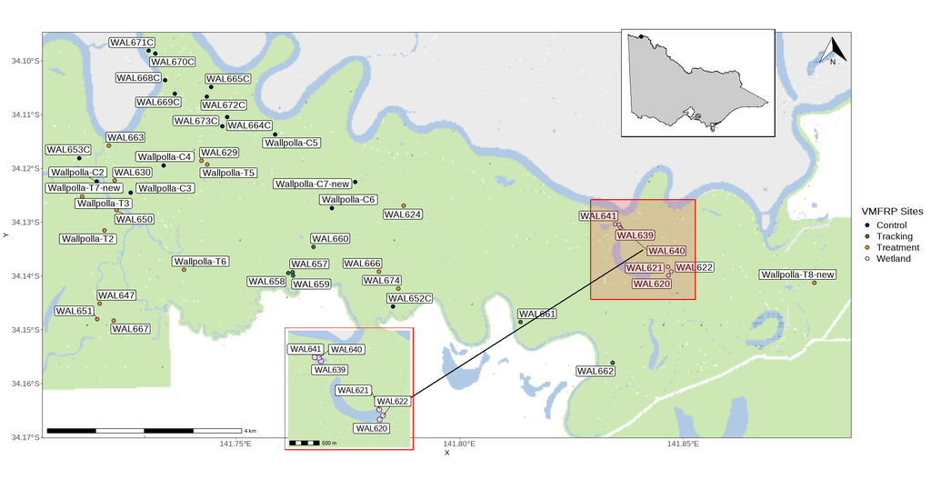

# Agent Approach (🪱)

Warning: If you did not attend module 1, there will be bits that you may be confused by. Try to focus on the bigger picture and then later have a look at Module 1 link and the recording

Okay, Paul tackled the task as a Human-in-the-loop (HITL) approach in which the human has minimal coding skills.

Now, let’s approach again using an `Agent` workflow.

**Disclaimer:** As noted during Module 1, we are not advocating for any approach, rather we are viewing this as a learning opportunity to better understand `Agents` and their capabilities.

We understand if you have feeling about `Agents` more like…

[figure not shown]

## Steps using Posit AI (aka Posit Assistant)

Let’s walk through a workflow…

### Step 1: set-up the project folder with the data

I have already created a folder [download project setup for Agent](https://delwpvicgovau-my.sharepoint.com/:u:/g/personal/ben_fanson_deeca_vic_gov_au/IQDimWRQjD71Rru9ZC8LWTYsAciQSIKLmHbmgwI0xafqljA?e=AeGKMQ)

Let’s have a look around the folder as there are few things in there that I added from the Copilot approach above.

The basic structure of the project folder is …

```
├── 2026_Module3.Rproj
├── AGENTS.MD
├── Prompt.MD
├── data
│   ├── raw
│   └── spatial
│       └── vmfrp_wallpolla_veg.gpkg
├── figures
│   └── qgis_goal.png
├── .posit
│   ├── SKILLS
│   │   └── spatial_analyst
│   │       └── SKILL.md
│   └── STYLE.md
```

Let’s have a look at the agent file…(snapshot of the top)

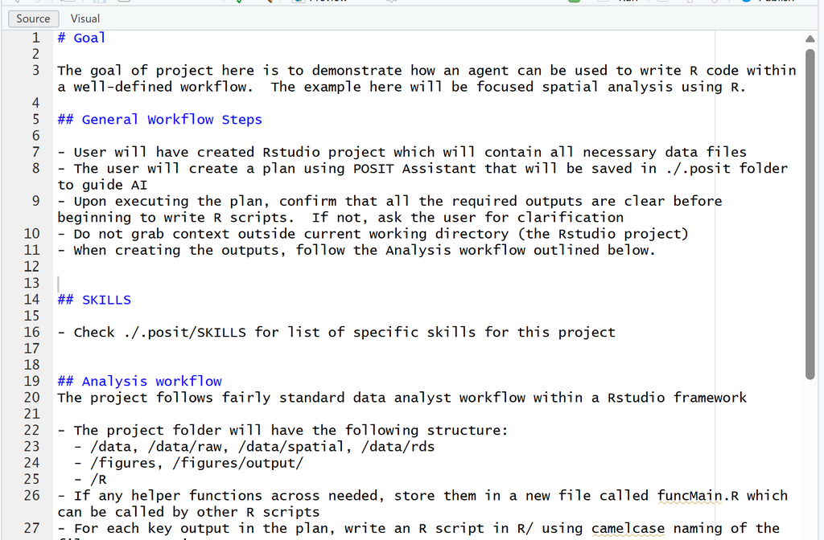

And the spatial_analyst skill…(snapshot of the top)

[figure not shown]

### Step 2: Use plan mode

Before diving into getting the spatial code, you need to have an idea/plan of what you want the `Agent` to do. The ‘plan mode’ can be useful for this.

**PROMPT**

*/plan (sets to plan mode)*

I need to create a png map using an R workflow. I have a graph (figures/qgis_goal.png) that I want you to replicate. I first want to create a plan that we argue on to create similar map output (‘figures/rmap.png’) and all points will be `data/spatial/vmfrp_wallpolla_veg.gpkg`. A basemap and Victorian layer will be needed to be found. See `.posit/AGENTS.MD` ‘.posit/spatial_analyst/’ skill to guide workflow approach. During the planning stage, do not guess what I want but rather ask me explicitly. Save the plan as PLAN.MD in base directory.

Run plan mode…

[figure not shown]

We will work through this live. An example of what might come out is shown below:

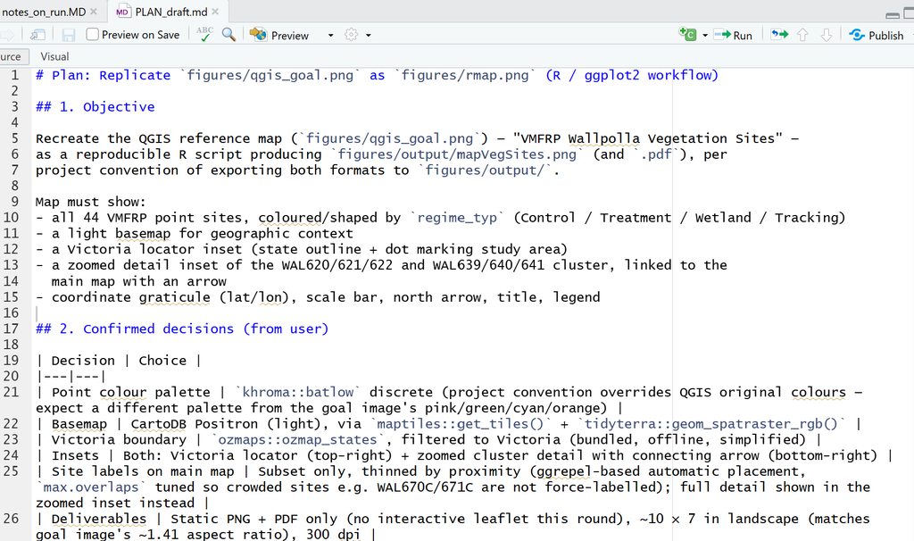

MD files are Markdown and very commonly used in programming world as they are a balance between between .txt file with no formatting and Word doc (excessive formatting😊). See [Intro to Markdown](https://www.markdownguide.org/getting-started/)

### Step 3: Execute the plan

Okay, we got a plan and told AI what we want. Let’s implement the plan and see how it does. I will mostly go YOLO ( **Y**ou **O**nly **L**ook **O**nce). I want to see what it can do.

I will run Claude Sonnet 5.0 for the example here.

### Step 4: Review the results

Let’s walk through some of the outputs.

**Initial draft…**

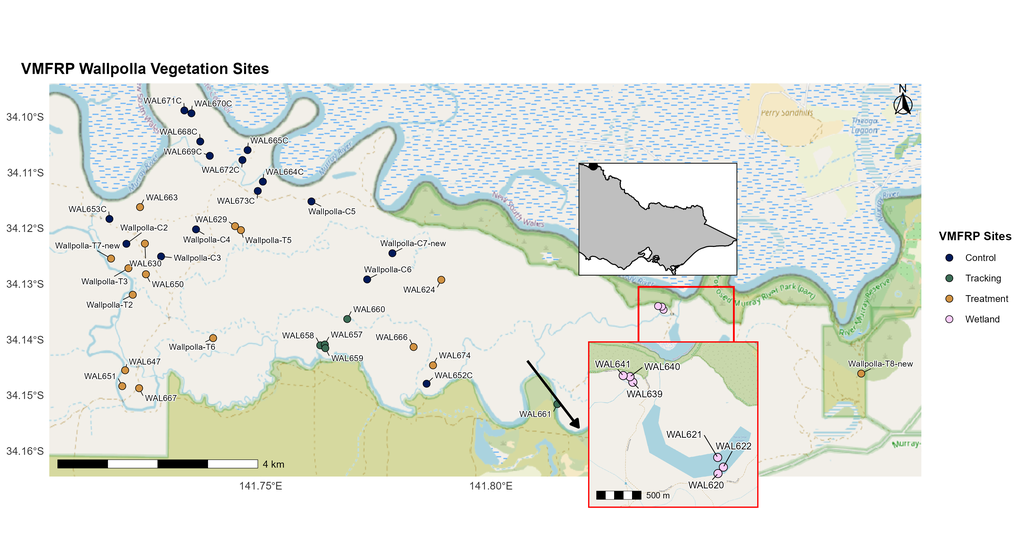

### Step 5: Iterate (as needed)

It is very likely the output is not quite there (or worse)…

[figure not shown]

**PROMPT**

*/plan (sets to plan mode)*

Using the qgis_goal.png, compare and contrast to rmap.png and provide a list of changes needed to rmap.png to make it match better. When implementing, save new png as rmap_final.png

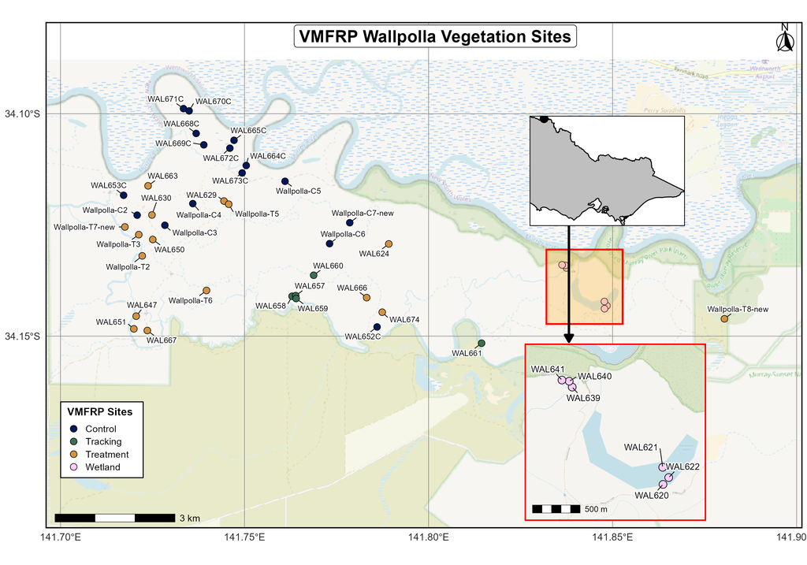

**ORIGINAL QGIS**

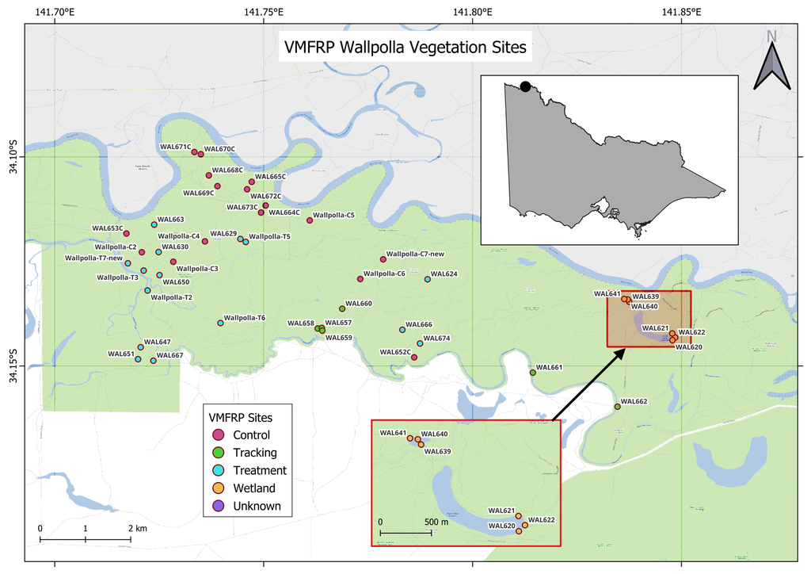

## Back to folder structure

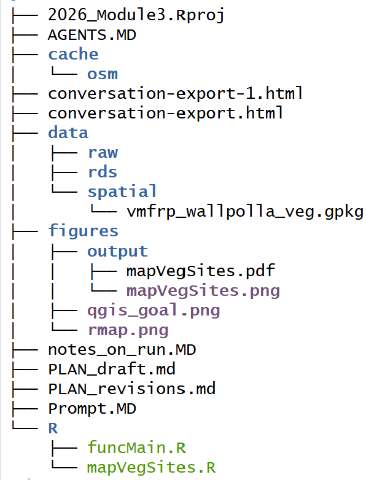

## Comparing LLMs results

As this is stochastic and depends on the model, you will get different results. Out of curiosity, I ran multiple iterations using the exact same plan.

**GLM 5.3 First**

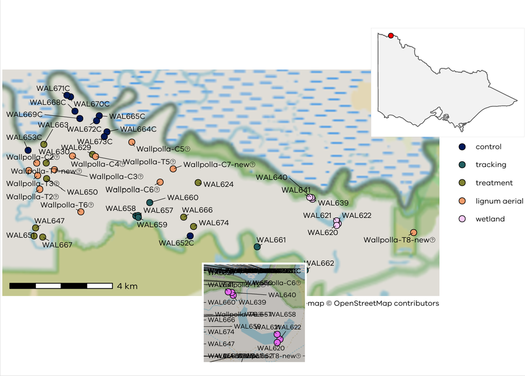

**GLM 5.3 Second**

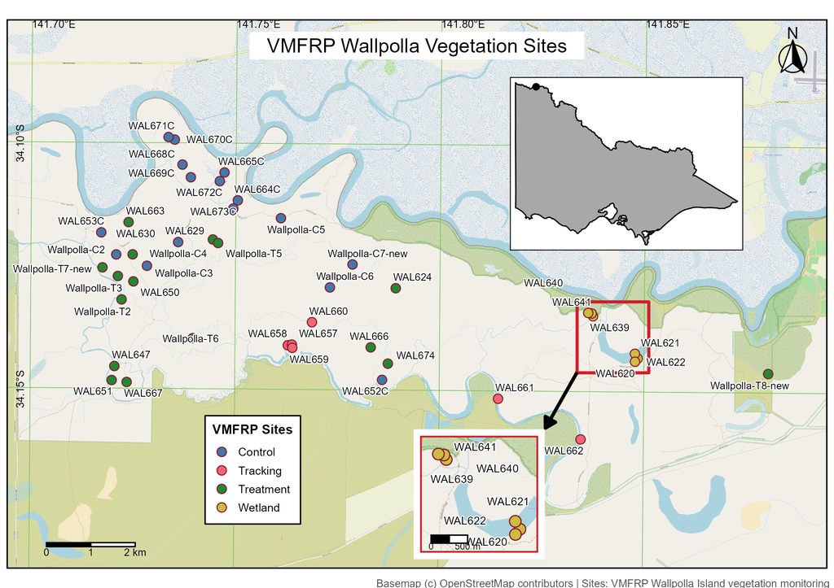

**Claude Haiku**

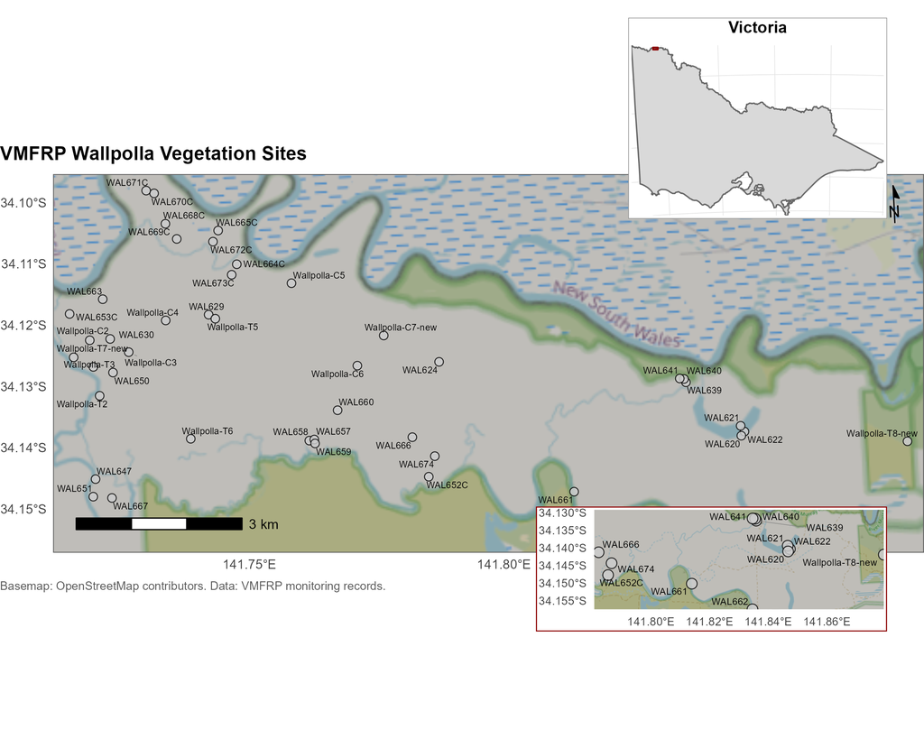

**KIMI K3**

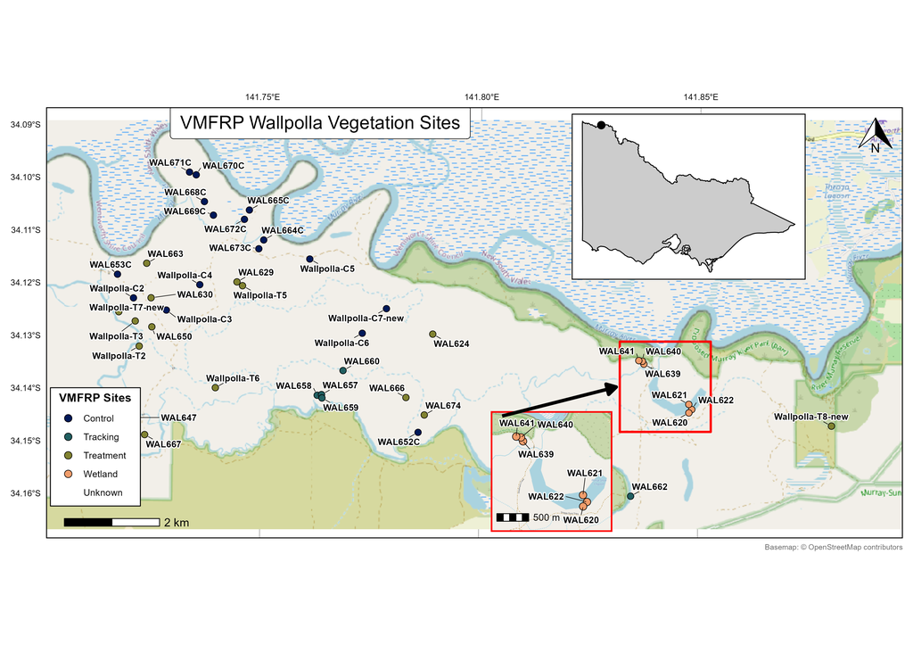

### Summary table of insights…

| Rank | Model | ~Cost | Thoughts |
| --- | --- | --- | --- |
| 1 | Claude Sonnet (1.0x) | $3.30 | More expensive model but it viewed the png file with no issues and just needed to ask a few questions. It was able to evaluate how well it had done and fix several components |
| 1-2nd attempt | GLM 5.3 (0.6x) | $1.20 | On second attempt (a few days later), it was able to create a subagent as a viewer. It re-iterated by itself to really get final map (no prompting from me). Did it learn from previous attempt?? |
| 3 | Kimi (0.9x) | $4.66 | First draft was very close. It seemed to evaluate along the way, so the final revision prompt not as needed. |
| 4-1st attempt | GLM 5.3 (0.6x) | $1.00 | First try, not able to “view” the png so had to try to walk it through via queries. Output was pretty poor. |
| 4 | Claude Haiku (0.4x) | $0.72 | Least expensive model I tried. Clunkier in how its ask question. Did not suggest/recommend approaches. Created 6 script files |

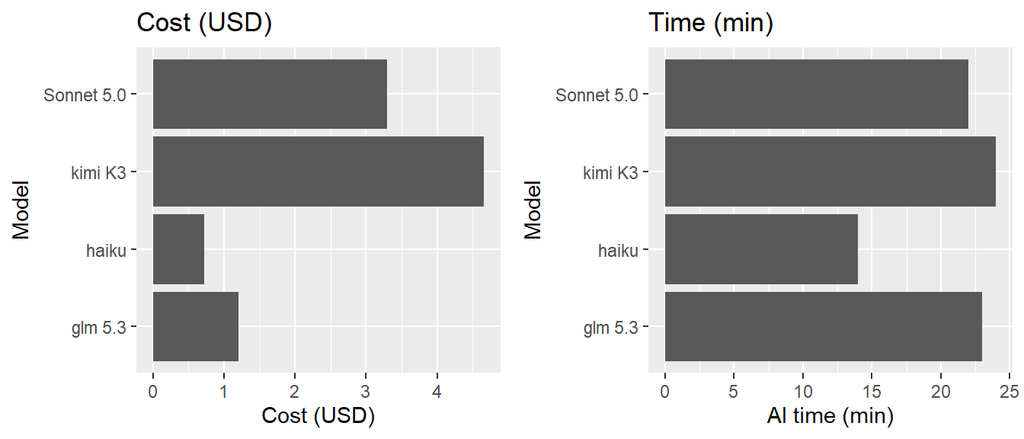

# Coming back to vibe-coding idea

## Some final thoughts

*Disclaimer: This is us free-thinking in real time during a paradign shift. Feel free to disagree or contribute your own thoughts.*

### Resist intellectual laziness

This is not a flippant statement.

As AI tools become more capable, there is a risk that we outsource not only the coding, but also the thinking.

Contributing factors:

- We are increasingly time-stressed.
- Projects often have unrealistic deadlines.
- Vibe-coding can create psychological distance from the underlying problem.
- Modern digital platforms reward speed, visibility, and confidence more than deep understanding.
- AI can produce plausible outputs that reduce the incentive to question assumptions or verify results.

**Key message:** The danger is not that AI writes code. The danger is that we stop engaging critically with the problem we are trying to solve.

### Reviewing the code

- Despite the temptation, we are going to need to be disciplined about reading the code and ensure that we understand exactly what it is doing.
- Not all code requires the same level of assessment (importing data vs ggplot vs statistical analysis)
- Learning how to QC/QA your code and outputs will increase in importance
- As noted, I have a STYLE.MD guide that writes the code in my style. That helps me review/evaluate the code quicker.

### Learning from vibe-coding

- New approaches to tackling a problem (plan mode)
- Reading the code that the Agent wrote introduced me to new functions/approaches to making new maps

### Beyond spatial data

- Obviously, **vibe-coding is not restricted to spatial data** and you can implement the same approach to other type of data.

### Homogensing workflow (the future)

An emerging question that we are wondering about (and we mentioned in module 1…sorry to dwell) is what does this mean for how we tackle these steps in the future and our workflows.

How homogenized do our workflows become?

- Standardised ARI STYLE.MD, WOKFLOW.MD, and set of SKILLS.MD files/folders.
- Do we have a project folder that has a similar structure so both humans and a local LLM that has been trained on our workflow can easily understand it, revise, and QC it?

All of this seems apt given all the discussion on templates/standardisation

### “The Castle” references feel rather appropriate at this point in time…

[figure not shown]

[figure not shown]

## Footnotes

[^1]: Some people have access to Copilot Professional, which may perform better than Copilot Basic in these tasks.
[^2]: Context rot is when the LLM starts to lose track of the conversation as it goes on for a while. It is also called context drift, and can bepart of the “Lost in the Middle” problem.